# gtsummary 패키지 소개

Yujin Lee

2022-02-03

# 시작하기 전에

본 자료에서는 데이터 셋의 변수를 하나의 테이블로 요약하는 방법에 대해 알아볼 것이다. **gtsummary** 패키지를 이용하면 효율적으로 논문에 들어갈 table1을 만들 수 있다. **gtsummary** 패키지에 관한 기본 개념 및 함수들을 예제를 통해 다루어 보자.

# 요약 테이블 만들기

**tbl_summary** 함수를 이용하여 연속형 및 범주형 변수에 대한 기술 통계량을 계산하고 테이블 형태로 나타낼 수 있다.

## Setup

```r
## Setup

# install.packages("data.table")
# install.packages("gtsummary")
library(data.table)
library(gtsummary)
```

## Road file

```r
## Load file

url <- "https://raw.githubusercontent.com/jinseob2kim/lecture-snuhlab/master/data/example_g1e.csv"
dt <- fread(url,header=T)
dt
```

| EXMD_BZ_YYYY | RN_INDI | HME_YYYYMM | Q_PHX_DX_STK | Q_PHX_DX_HTDZ | Q_PHX_DX_HTN | Q_PHX_DX_DM | Q_PHX_DX_DLD | Q_PHX_DX_PTB | Q_HBV_AG | Q_SMK_YN | Q_DRK_FRQ_V09N | HGHT | WGHT | WSTC | BMI | VA_LT | VA_RT | BP_SYS | BP_DIA | URN_PROT | HGB | FBS | TOT_CHOL | TG | HDL | LDL | CRTN | SGOT | SGPT | … |
| --- | --- | --- | --- | --- | --- | --- | --- | --- | --- | --- | --- | --- | --- | --- | --- | --- | --- | --- | --- | --- | --- | --- | --- | --- | --- | --- | --- | --- | --- | --- |
| 2009 | 562083 | 200909 | 0 | 0 | 1 | 0 | 0 | NA | 3 | 1 | 0 | 144 | 61 | 90 | 29.4 | 0.7 | 0.8 | 120 | 80 | 1 | 12.6 | 117 | 264 | 128 | 60 | 179 | 0.9 | 25 | 20 | … |
| 2009 | 334536 | 200911 | 0 | 0 | 0 | 0 | 0 | NA | 2 | 1 | 0 | 162 | 51 | 63 | 19.4 | 0.8 | 1.0 | 120 | 80 | 1 | 13.8 | 96 | 169 | 92 | 70 | 80 | 0.9 | 18 | 15 | … |
| 2009 | 911867 | 200903 | 0 | 0 | 0 | 0 | 0 | NA | 3 | 1 | 0 | 163 | 65 | 82 | 24.5 | 0.7 | 0.6 | 130 | 80 | 1 | 15.0 | 118 | 216 | 132 | 55 | 134 | 0.8 | 26 | 30 | … |
| 2009 | 183321 | 200908 | NA | NA | NA | NA | NA | NA | 3 | 1 | 0 | 152 | 51 | 70 | 22.1 | 0.8 | 0.9 | 101 | 62 | 1 | 13.1 | 90 | 199 | 100 | 65 | 114 | 0.9 | 18 | 14 | … |
| 2009 | 942671 | 200909 | NA | NA | NA | NA | NA | NA | 3 | 1 | 0 | 159 | 50 | 73 | 19.8 | 0.7 | 0.8 | 132 | 78 | 1 | 13.0 | 92 | 162 | 58 | 40 | 111 | 0.9 | 24 | 23 | … |
| 2009 | 979358 | 200912 | NA | NA | NA | NA | NA | NA | 2 | 1 | 0 | 157 | 55 | 73 | 22.3 | 1.5 | 1.5 | 110 | 70 | 1 | 11.9 | 100 | 192 | 109 | 53 | 117 | 0.7 | 15 | 12 | … |
| 2009 | 554112 | 200911 | NA | NA | NA | NA | NA | NA | 2 | 1 | 0 | 160 | 56 | 67 | 21.9 | 1.5 | 1.5 | 119 | 78 | 1 | 11.2 | 84 | 152 | 38 | 43 | 101 | 0.8 | 8 | 6 | … |
| 2009 | 487160 | 200908 | NA | NA | NA | NA | NA | NA | 3 | 1 | 0 | 159 | 54 | 66 | 21.4 | 1.2 | 1.5 | 111 | 60 | 1 | 12.2 | 88 | 166 | 42 | 58 | 99 | 1.0 | 16 | 11 | … |
| 2009 | 793017 | 200906 | NA | NA | NA | NA | NA | NA | 3 | 1 | 0 | 156 | 53 | 67 | 21.8 | 1.2 | 1.0 | 138 | 72 | 1 | 11.0 | 74 | 155 | 86 | 52 | 85 | 0.6 | 15 | 13 | … |
| 2009 | 219397 | 200912 | 0 | 0 | 1 | 0 | 0 | NA | 3 | 1 | 0 | 146 | 48 | 78 | 22.5 | 1.5 | 1.5 | 138 | 84 | 1 | 12.8 | 107 | 178 | 87 | 35 | 125 | 0.7 | 21 | 21 | … |

[output cut: 1634 more lines]

## tbl_summary

**tbl_summary** 함수를 사용하여 기본 테이블을 작성할 수 있다. 출력값으로 데이터 셋의 각 열에 대한 기술 통계량을 반환한다. 데이터 셋에 섞인 범주형 변수와 연속형 변수를 자동적으로 인식해 그에 맞는 값을 반환하며, 범주형 변수의 기본 출력값은 n(%)이고 연속형 변수의 기본 출력값은 median(IQR)이다. 결측값은 테이블에 Unknown으로 출력된다.

`fread`를 통해 불러온 데이터에서 몇 개의 변수를 추출해 요약 테이블을 만들어보자.

```r
# select variables

dt2 <- dt %>% select("EXMD_BZ_YYYY", "Q_PHX_DX_STK", "Q_SMK_YN",
                     "HGHT", "WGHT" ,"TOT_CHOL", "TG")
dt2
```

| EXMD_BZ_YYYY | Q_PHX_DX_STK | Q_SMK_YN | HGHT | WGHT | TOT_CHOL | TG |
| --- | --- | --- | --- | --- | --- | --- |
| 2009 | 0 | 1 | 144 | 61 | 264 | 128 |
| 2009 | 0 | 1 | 162 | 51 | 169 | 92 |
| 2009 | 0 | 1 | 163 | 65 | 216 | 132 |
| 2009 | NA | 1 | 152 | 51 | 199 | 100 |
| 2009 | NA | 1 | 159 | 50 | 162 | 58 |
| 2009 | NA | 1 | 157 | 55 | 192 | 109 |
| 2009 | NA | 1 | 160 | 56 | 152 | 38 |
| 2009 | NA | 1 | 159 | 54 | 166 | 42 |
| 2009 | NA | 1 | 156 | 53 | 155 | 86 |
| 2009 | 0 | 1 | 146 | 48 | 178 | 87 |

[output cut: 1634 more lines]

`tbl_summary` 함수를 통해 간단한 요약 테이블을 만들어보자.

```r
# create table

dt2 %>% tbl_summary()
```

| **Characteristic** | **N = 1,644**<sup>1</sup> |
| --- | --- |
| EXMD_BZ_YYYY |  |
| 2009 | 214 (13%) |
| 2010 | 236 (14%) |
| 2011 | 223 (14%) |
| 2012 | 234 (14%) |
| 2013 | 243 (15%) |
| 2014 | 254 (15%) |
| 2015 | 240 (15%) |
| Q_PHX_DX_STK | 12 (1.1%) |
| Unknown | 573 |
| Q_SMK_YN |  |
| 1 | 995 (61%) |
| 2 | 256 (16%) |
| 3 | 391 (24%) |
| Unknown | 2 |
| HGHT | 165 (158, 171) |
| WGHT | 64 (56, 73) |
| TOT_CHOL | 193 (170, 218) |
| TG | 106 (72, 163) |

<sup>*1*</sup> n (%); Median (IQR)

- 변수 유형이 자동으로 구분되어 연속형 변수는 median(IQR), 범주형 변수는 n(%)의 형태로 출력된 것을 볼 수 있다.

## 그룹별 통계 by

`tbl_summary` 함수에는 다양한 옵션이 존재한다. **by** 옵션을 이용하여 그룹별 통계량을 계산할 수 있다. **by** 옵션에 그룹별 통계를 수행할 변수를 지정하여 사용 가능하다. 다음 예시에서 연도 변수인 EXMD_BZ_YYYY를 기준으로 그룹별 통계량을 출력해보자.

```r
dt2 %>% tbl_summary(by="EXMD_BZ_YYYY")
```

| **Characteristic** | **2009**, N = 214<sup>1</sup> | **2010**, N = 236<sup>1</sup> | **2011**, N = 223<sup>1</sup> | **2012**, N = 234<sup>1</sup> | **2013**, N = 243<sup>1</sup> | **2014**, N = 254<sup>1</sup> | **2015**, N = 240<sup>1</sup> |
| --- | --- | --- | --- | --- | --- | --- | --- |
| Q_PHX_DX_STK | 2 (1.5%) | 2 (1.2%) | 1 (0.7%) | 2 (1.3%) | 2 (1.2%) | 2 (1.3%) | 1 (0.6%) |
| Unknown | 82 | 74 | 85 | 78 | 75 | 95 | 84 |
| Q_SMK_YN |  |  |  |  |  |  |  |
| 1 | 125 (59%) | 132 (56%) | 140 (63%) | 146 (62%) | 141 (58%) | 157 (62%) | 154 (64%) |
| 2 | 34 (16%) | 42 (18%) | 35 (16%) | 36 (15%) | 35 (14%) | 38 (15%) | 36 (15%) |
| 3 | 53 (25%) | 62 (26%) | 48 (22%) | 52 (22%) | 67 (28%) | 59 (23%) | 50 (21%) |
| Unknown | 2 | 0 | 0 | 0 | 0 | 0 | 0 |
| HGHT | 165 (159, 171) | 165 (159, 171) | 165 (157, 171) | 164 (159, 172) | 165 (159, 171) | 164 (158, 172) | 164 (158, 172) |
| WGHT | 64 (55, 72) | 64 (56, 73) | 63 (56, 72) | 64 (57, 74) | 64 (57, 72) | 63 (56, 72) | 64 (57, 74) |
| TOT_CHOL | 192 (170, 216) | 193 (168, 220) | 190 (168, 214) | 196 (173, 224) | 190 (168, 218) | 193 (171, 216) | 194 (171, 217) |
| TG | 105 (71, 148) | 107 (70, 158) | 104 (74, 164) | 108 (69, 164) | 107 (76, 160) | 108 (75, 162) | 111 (71, 167) |

<sup>*1*</sup> n (%); Median (IQR)

## Modifying function arguments

`tbl_summary` 함수에는 다양한 옵션이 존재하며, 이러한 옵션 조정을 통해 원하는 테이블을 작성할 수 있다. 다음은 `tbl_summary` 함수의 주요 옵션에 대한 설명이다.

- label : 테이블에 출력되는 변수명 지정
- type : 변수 유형 지정 (ex. 연속형, 범주형)
- statistic : 요약 통계량 지정
- digits : 자릿수 지정
- missing : 결측값이 있는 행을 표시할지 여부
- missing_text : 결측행의 변수명 지정
- sort : 빈도에 따라 범주형 변수의 level 정렬
- percent : 열/행의 백분율 출력
- include : 테이블에 포함할 변수 지정

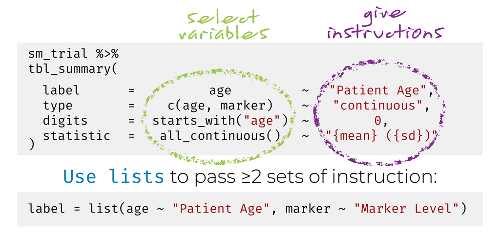

다음은 옵션을 활용한 예시이다. 연도 변수 EXMD_BZ_YYYY의 그룹별 통계량을 출력하고, Q_SMK_YN 변수를 “smoking y/n”로 바꾸어보자. 이때 연속형 변수의 출력값을 {mean}({sd})으로, 범주형 변수의 출력값을 {n}/{N} ({p}%) 형태로 바꾸어보자. 결측값의 변수명은 “Missing”으로 수정한다.

```r
dt2 %>%
  tbl_summary(
    by = EXMD_BZ_YYYY,
    statistic = list(all_continuous() ~ "{mean} ({sd})",
                     all_categorical() ~ "{n} / {N} ({p}%)"),
    label = Q_SMK_YN ~ "smoking y/n",
    missing_text = "Missing"
  )
```

| **Characteristic** | **2009**, N = 214<sup>1</sup> | **2010**, N = 236<sup>1</sup> | **2011**, N = 223<sup>1</sup> | **2012**, N = 234<sup>1</sup> | **2013**, N = 243<sup>1</sup> | **2014**, N = 254<sup>1</sup> | **2015**, N = 240<sup>1</sup> |
| --- | --- | --- | --- | --- | --- | --- | --- |
| Q_PHX_DX_STK | 2 / 132 (1.5%) | 2 / 162 (1.2%) | 1 / 138 (0.7%) | 2 / 156 (1.3%) | 2 / 168 (1.2%) | 2 / 159 (1.3%) | 1 / 156 (0.6%) |
| Missing | 82 | 74 | 85 | 78 | 75 | 95 | 84 |
| smoking y/n |  |  |  |  |  |  |  |
| 1 | 125 / 212 (59%) | 132 / 236 (56%) | 140 / 223 (63%) | 146 / 234 (62%) | 141 / 243 (58%) | 157 / 254 (62%) | 154 / 240 (64%) |
| 2 | 34 / 212 (16%) | 42 / 236 (18%) | 35 / 223 (16%) | 36 / 234 (15%) | 35 / 243 (14%) | 38 / 254 (15%) | 36 / 240 (15%) |
| 3 | 53 / 212 (25%) | 62 / 236 (26%) | 48 / 223 (22%) | 52 / 234 (22%) | 67 / 243 (28%) | 59 / 254 (23%) | 50 / 240 (21%) |
| Missing | 2 | 0 | 0 | 0 | 0 | 0 | 0 |
| HGHT | 164 (9) | 165 (9) | 164 (10) | 165 (9) | 165 (9) | 164 (9) | 164 (9) |
| WGHT | 64 (13) | 65 (12) | 65 (13) | 66 (12) | 65 (12) | 64 (12) | 66 (13) |
| TOT_CHOL | 195 (37) | 195 (39) | 194 (38) | 199 (35) | 192 (36) | 195 (36) | 195 (36) |
| TG | 129 (90) | 136 (101) | 138 (108) | 129 (89) | 132 (98) | 138 (127) | 141 (113) |

<sup>*1*</sup> n / N (%); Mean (SD)

# functions to add information

gtsummary 패키지에는 **add_()** 함수를 이용하여 테이블에 통계 정보를 추가하는 기능이 있다. 다음은 **add_()** 함수들의 주요 설명이다.

- add_p() : 그룹 간 값의 비교를 위한 p-value 추가
- add_overall() : 전체 요약 통계량을 출력하는 열 추가
- add_n() : 각 변수의 행 수와 결측행 개수 추가
- add_difference() : 두 그룹 간의 차이, 신뢰구간 및 p-value 추가
- add_stat_label() : 요약 통계량의 label 추가
- add_stat() : 사용자 지정 함수 추가
- add_q() : 다중 비교를 위한 q-value 추가

**add_p()** 함수를 사용하여 `tbl_summary`에 의해 생성된 테이블에 p-value를 추가할 수 있다. 이때 test 인자에 “t.test”, “wilcox.test”, “chisq.test”, “fisher.test” 와 같은 수행할 통계 테스트를 지정할 수 있다. **add_p(col ~ “.test”)** 형식을 사용하며 모든 변수 또는 일부 변수에 대해 적용할 수 있다.

(default test: 연속형 변수 - 2그룹 **wilcox.test**, 3그룹 이상 **kruskal.test** 범주형 변수 - 행의 수가 5 이상인 경우 **chisq.test**, 5 미만인 경우 **fisher.test**)

1. 연속형 변수 - **“t.test”**, **“wilcox.test”**

```r
dt2 %>%
  tbl_summary(by=Q_PHX_DX_STK) %>%
  add_p(all_continuous()~"t.test")
```

| **Characteristic** | **0**, N = 1,059<sup>1</sup> | **1**, N = 12<sup>1</sup> | **p-value**<sup>2</sup> |
| --- | --- | --- | --- |
| EXMD_BZ_YYYY |  |  | >0.9 |
| 2009 | 130 (12%) | 2 (17%) |  |
| 2010 | 160 (15%) | 2 (17%) |  |
| 2011 | 137 (13%) | 1 (8.3%) |  |
| 2012 | 154 (15%) | 2 (17%) |  |
| 2013 | 166 (16%) | 2 (17%) |  |
| 2014 | 157 (15%) | 2 (17%) |  |
| 2015 | 155 (15%) | 1 (8.3%) |  |
| Q_SMK_YN |  |  | 0.045 |
| 1 | 608 (58%) | 11 (92%) |  |
| 2 | 186 (18%) | 1 (8.3%) |  |
| 3 | 263 (25%) | 0 (0%) |  |
| Unknown | 2 | 0 |  |
| HGHT | 166 (160, 172) | 159 (155, 170) | 0.064 |
| WGHT | 65 (58, 73) | 64 (56, 66) | 0.051 |
| TOT_CHOL | 194 (171, 218) | 163 (146, 192) | 0.035 |
| TG | 108 (73, 163) | 128 (116, 148) | 0.5 |

<sup>*1*</sup> n (%); Median (IQR) <sup>*2*</sup> Fisher's exact test; Welch Two Sample t-test

```r
dt2 %>%
  tbl_summary(by=Q_PHX_DX_STK) %>%
  add_p(HGHT~"wilcox.test")
```

| **Characteristic** | **0**, N = 1,059<sup>1</sup> | **1**, N = 12<sup>1</sup> | **p-value**<sup>2</sup> |
| --- | --- | --- | --- |
| EXMD_BZ_YYYY |  |  | >0.9 |
| 2009 | 130 (12%) | 2 (17%) |  |
| 2010 | 160 (15%) | 2 (17%) |  |
| 2011 | 137 (13%) | 1 (8.3%) |  |
| 2012 | 154 (15%) | 2 (17%) |  |
| 2013 | 166 (16%) | 2 (17%) |  |
| 2014 | 157 (15%) | 2 (17%) |  |
| 2015 | 155 (15%) | 1 (8.3%) |  |
| Q_SMK_YN |  |  | 0.045 |
| 1 | 608 (58%) | 11 (92%) |  |
| 2 | 186 (18%) | 1 (8.3%) |  |
| 3 | 263 (25%) | 0 (0%) |  |
| Unknown | 2 | 0 |  |
| HGHT | 166 (160, 172) | 159 (155, 170) | 0.048 |
| WGHT | 65 (58, 73) | 64 (56, 66) | 0.2 |
| TOT_CHOL | 194 (171, 218) | 163 (146, 192) | 0.022 |
| TG | 108 (73, 163) | 128 (116, 148) | 0.10 |

<sup>*1*</sup> n (%); Median (IQR) <sup>*2*</sup> Fisher's exact test; Wilcoxon rank sum test

2. 범주형 변수 - **“chisq.test”**, **“fisher.test”**

```r
dt2 %>%
  tbl_summary(by=Q_PHX_DX_STK) %>%
  add_p(all_categorical()~"chisq.test")
```

| **Characteristic** | **0**, N = 1,059<sup>1</sup> | **1**, N = 12<sup>1</sup> | **p-value**<sup>2</sup> |
| --- | --- | --- | --- |
| EXMD_BZ_YYYY |  |  | >0.9 |
| 2009 | 130 (12%) | 2 (17%) |  |
| 2010 | 160 (15%) | 2 (17%) |  |
| 2011 | 137 (13%) | 1 (8.3%) |  |
| 2012 | 154 (15%) | 2 (17%) |  |
| 2013 | 166 (16%) | 2 (17%) |  |
| 2014 | 157 (15%) | 2 (17%) |  |
| 2015 | 155 (15%) | 1 (8.3%) |  |
| Q_SMK_YN |  |  | 0.051 |
| 1 | 608 (58%) | 11 (92%) |  |
| 2 | 186 (18%) | 1 (8.3%) |  |
| 3 | 263 (25%) | 0 (0%) |  |
| Unknown | 2 | 0 |  |
| HGHT | 166 (160, 172) | 159 (155, 170) | 0.048 |
| WGHT | 65 (58, 73) | 64 (56, 66) | 0.2 |
| TOT_CHOL | 194 (171, 218) | 163 (146, 192) | 0.022 |
| TG | 108 (73, 163) | 128 (116, 148) | 0.10 |

<sup>*1*</sup> n (%); Median (IQR) <sup>*2*</sup> Pearson's Chi-squared test; Wilcoxon rank sum test

```r
dt2 %>%
  tbl_summary(by=Q_PHX_DX_STK) %>%
  add_p(Q_SMK_YN ~ "fisher.test")
```

| **Characteristic** | **0**, N = 1,059<sup>1</sup> | **1**, N = 12<sup>1</sup> | **p-value**<sup>2</sup> |
| --- | --- | --- | --- |
| EXMD_BZ_YYYY |  |  | >0.9 |
| 2009 | 130 (12%) | 2 (17%) |  |
| 2010 | 160 (15%) | 2 (17%) |  |
| 2011 | 137 (13%) | 1 (8.3%) |  |
| 2012 | 154 (15%) | 2 (17%) |  |
| 2013 | 166 (16%) | 2 (17%) |  |
| 2014 | 157 (15%) | 2 (17%) |  |
| 2015 | 155 (15%) | 1 (8.3%) |  |
| Q_SMK_YN |  |  | 0.045 |
| 1 | 608 (58%) | 11 (92%) |  |
| 2 | 186 (18%) | 1 (8.3%) |  |
| 3 | 263 (25%) | 0 (0%) |  |
| Unknown | 2 | 0 |  |
| HGHT | 166 (160, 172) | 159 (155, 170) | 0.048 |
| WGHT | 65 (58, 73) | 64 (56, 66) | 0.2 |
| TOT_CHOL | 194 (171, 218) | 163 (146, 192) | 0.022 |
| TG | 108 (73, 163) | 128 (116, 148) | 0.10 |

<sup>*1*</sup> n (%); Median (IQR) <sup>*2*</sup> Fisher's exact test; Wilcoxon rank sum test

이외에 다양한 **add_()**함수를 이용하여 앞에서 만든 table에 여러 통계량을 추가해보자.

```r
dt2 %>%
  tbl_summary(by="EXMD_BZ_YYYY") %>%
  add_p() %>%
  add_overall() %>%
  add_n() %>%
  add_q()
```

| **Characteristic** | **N** | **Overall**, N = 1,644<sup>1</sup> | **2009**, N = 214<sup>1</sup> | **2010**, N = 236<sup>1</sup> | **2011**, N = 223<sup>1</sup> | **2012**, N = 234<sup>1</sup> | **2013**, N = 243<sup>1</sup> | **2014**, N = 254<sup>1</sup> | **2015**, N = 240<sup>1</sup> | **p-value**<sup>2</sup> | **q-value**<sup>3</sup> |
| --- | --- | --- | --- | --- | --- | --- | --- | --- | --- | --- | --- |
| Q_PHX_DX_STK | 1,071 | 12 (1.1%) | 2 (1.5%) | 2 (1.2%) | 1 (0.7%) | 2 (1.3%) | 2 (1.2%) | 2 (1.3%) | 1 (0.6%) | >0.9 | >0.9 |
| Unknown |  | 573 | 82 | 74 | 85 | 78 | 75 | 95 | 84 |  |  |
| Q_SMK_YN | 1,642 |  |  |  |  |  |  |  |  | 0.9 | >0.9 |
| 1 |  | 995 (61%) | 125 (59%) | 132 (56%) | 140 (63%) | 146 (62%) | 141 (58%) | 157 (62%) | 154 (64%) |  |  |
| 2 |  | 256 (16%) | 34 (16%) | 42 (18%) | 35 (16%) | 36 (15%) | 35 (14%) | 38 (15%) | 36 (15%) |  |  |
| 3 |  | 391 (24%) | 53 (25%) | 62 (26%) | 48 (22%) | 52 (22%) | 67 (28%) | 59 (23%) | 50 (21%) |  |  |
| Unknown |  | 2 | 2 | 0 | 0 | 0 | 0 | 0 | 0 |  |  |
| HGHT | 1,644 | 165 (158, 171) | 165 (159, 171) | 165 (159, 171) | 165 (157, 171) | 164 (159, 172) | 165 (159, 171) | 164 (158, 172) | 164 (158, 172) | >0.9 | >0.9 |
| WGHT | 1,644 | 64 (56, 73) | 64 (55, 72) | 64 (56, 73) | 63 (56, 72) | 64 (57, 74) | 64 (57, 72) | 63 (56, 72) | 64 (57, 74) | 0.8 | >0.9 |
| TOT_CHOL | 1,644 | 193 (170, 218) | 192 (170, 216) | 193 (168, 220) | 190 (168, 214) | 196 (173, 224) | 190 (168, 218) | 193 (171, 216) | 194 (171, 217) | 0.7 | >0.9 |
| TG | 1,644 | 106 (72, 163) | 105 (71, 148) | 107 (70, 158) | 104 (74, 164) | 108 (69, 164) | 107 (76, 160) | 108 (75, 162) | 111 (71, 167) | >0.9 | >0.9 |

<sup>*1*</sup> n (%); Median (IQR) <sup>*2*</sup> Fisher's exact test; Pearson's Chi-squared test; Kruskal-Wallis rank sum test <sup>*3*</sup> False discovery rate correction for multiple testing

- 각 변수의 p-value 및 q-value와 전체 요약 통계량, 행의 수가 출력된 것을 확인할 수 있다.

이번에는 두 그룹 간의 차이를 비교해보자.

```r
dt2 %>%
  tbl_summary(by=Q_PHX_DX_STK) %>%
  add_difference()
```

| **Characteristic** | **0**, N = 1,059<sup>1</sup> | **1**, N = 12<sup>1</sup> | **p-value**<sup>2</sup> | **Difference**<sup>2</sup> | **95% CI**<sup>2,3</sup> |
| --- | --- | --- | --- | --- | --- |
| EXMD_BZ_YYYY |  |  |  |  |  |
| 2009 | 130 (12%) | 2 (17%) |  |  |  |
| 2010 | 160 (15%) | 2 (17%) |  |  |  |
| 2011 | 137 (13%) | 1 (8.3%) |  |  |  |
| 2012 | 154 (15%) | 2 (17%) |  |  |  |
| 2013 | 166 (16%) | 2 (17%) |  |  |  |
| 2014 | 157 (15%) | 2 (17%) |  |  |  |
| 2015 | 155 (15%) | 1 (8.3%) |  |  |  |
| Q_SMK_YN |  |  |  |  |  |
| 1 | 608 (58%) | 11 (92%) |  |  |  |
| 2 | 186 (18%) | 1 (8.3%) |  |  |  |
| 3 | 263 (25%) | 0 (0%) |  |  |  |
| Unknown | 2 | 0 |  |  |  |
| HGHT | 166 (160, 172) | 159 (155, 170) | 0.064 | 6.5 | -0.44, 14 |
| WGHT | 65 (58, 73) | 64 (56, 66) | 0.051 | 5.4 | -0.04, 11 |
| TOT_CHOL | 194 (171, 218) | 163 (146, 192) | 0.035 | 23 | 1.9, 43 |
| TG | 108 (73, 163) | 128 (116, 148) | 0.5 | -12 | -50, 26 |

<sup>*1*</sup> n (%); Median (IQR) <sup>*2*</sup> Welch Two Sample t-test <sup>*3*</sup> CI = Confidence Interval

- Q_PHX_DX_STK 변수의 두 그룹 간의 차이와 신뢰구간, p-value가 추가된 것을 볼 수 있다.

# functions to format table

gtsummary 패키지에는 테이블의 형식을 지정하는 함수 또한 존재한다. 다음과 같은 함수들을 사용하여 테이블의 디자인 및 형식을 설정할 수 있다.

- modify_header() : 테이블 header 형식 지정
- modify_footnote() : 테이블 각주 형식 지정
- modify_spanning_header() : 테이블 spanning header 형식 지정
- modify_caption() : 테이블 캡션 형식 지정
- bold_labels() : 변수명 볼드체
- bold_levels() : 범주 볼드체
- italicize_labels() : 변수명 기울임
- italicize_levels() : 범주 기울임
- bold_p() : p-value 볼드체

위의 함수들을 사용하여 테이블의 디자인을 설정해보자.

```r
dt2 %>%
  tbl_summary(by="EXMD_BZ_YYYY") %>%
  add_p() %>%
  add_n() %>%
  modify_header(label ~ "**Variables**") %>%
  modify_spanning_header(all_stat_cols() ~ "**Year**") %>%
  modify_footnote(all_stat_cols() ~ "Median(IQR) or Frequency(%)") %>%
  modify_caption("Table 1") %>%
  bold_labels()
```

Table 1

[output not shown]

<sup>*1*</sup> Median(IQR) or Frequency(%) <sup>*2*</sup> Fisher's exact test; Pearson's Chi-squared test; Kruskal-Wallis rank sum test

# Multi-line Continuous Summaries

연속형 변수의 통계량은 여러 줄로 요약될 수 있다. 여러 줄에 걸쳐 연속형 변수의 요약값을 출력할 때에는 변수 type을 **continuous2**로 지정해주어야 한다.

```r
dt2 %>%
  tbl_summary(
    by = "EXMD_BZ_YYYY",
    type = all_continuous() ~ "continuous2",
    statistic = all_continuous() ~ c("{N_nonmiss}",
                                     "{median} ({p25}, {p75})",
                                     "{min}, {max}"),
    missing = "no"
    ) %>%
  add_p()
```

| **Characteristic** | **2009**, N = 214<sup>1</sup> | **2010**, N = 236<sup>1</sup> | **2011**, N = 223<sup>1</sup> | **2012**, N = 234<sup>1</sup> | **2013**, N = 243<sup>1</sup> | **2014**, N = 254<sup>1</sup> | **2015**, N = 240<sup>1</sup> | **p-value**<sup>2</sup> |
| --- | --- | --- | --- | --- | --- | --- | --- | --- |
| Q_PHX_DX_STK | 2 (1.5%) | 2 (1.2%) | 1 (0.7%) | 2 (1.3%) | 2 (1.2%) | 2 (1.3%) | 1 (0.6%) | >0.9 |
| Q_SMK_YN |  |  |  |  |  |  |  | 0.9 |
| 1 | 125 (59%) | 132 (56%) | 140 (63%) | 146 (62%) | 141 (58%) | 157 (62%) | 154 (64%) |  |
| 2 | 34 (16%) | 42 (18%) | 35 (16%) | 36 (15%) | 35 (14%) | 38 (15%) | 36 (15%) |  |
| 3 | 53 (25%) | 62 (26%) | 48 (22%) | 52 (22%) | 67 (28%) | 59 (23%) | 50 (21%) |  |
| HGHT |  |  |  |  |  |  |  | >0.9 |
| N | 214 | 236 | 223 | 234 | 243 | 254 | 240 |  |
| Median (IQR) | 165 (159, 171) | 165 (159, 171) | 165 (157, 171) | 164 (159, 172) | 165 (159, 171) | 164 (158, 172) | 164 (158, 172) |  |
| Range | 139, 186 | 139, 186 | 134, 188 | 140, 188 | 139, 186 | 136, 185 | 138, 185 |  |
| WGHT |  |  |  |  |  |  |  | 0.8 |
| N | 214 | 236 | 223 | 234 | 243 | 254 | 240 |  |
| Median (IQR) | 64 (55, 72) | 64 (56, 73) | 63 (56, 72) | 64 (57, 74) | 64 (57, 72) | 63 (56, 72) | 64 (57, 74) |  |
| Range | 35, 110 | 31, 114 | 39, 114 | 39, 111 | 37, 117 | 31, 111 | 36, 118 |  |
| TOT_CHOL |  |  |  |  |  |  |  | 0.7 |
| N | 214 | 236 | 223 | 234 | 243 | 254 | 240 |  |
| Median (IQR) | 192 (170, 216) | 193 (168, 220) | 190 (168, 214) | 196 (173, 224) | 190 (168, 218) | 193 (171, 216) | 194 (171, 217) |  |
| Range | 112, 300 | 68, 324 | 74, 321 | 120, 300 | 83, 303 | 119, 341 | 101, 363 |  |
| TG |  |  |  |  |  |  |  | >0.9 |
| N | 214 | 236 | 223 | 234 | 243 | 254 | 240 |  |
| Median (IQR) | 105 (71, 148) | 107 (70, 158) | 104 (74, 164) | 108 (69, 164) | 107 (76, 160) | 108 (75, 162) | 111 (71, 167) |  |
| Range | 26, 654 | 25, 685 | 26, 723 | 24, 572 | 13, 1,017 | 24, 1,210 | 34, 878 |  |

<sup>*1*</sup> n (%) <sup>*2*</sup> Fisher's exact test; Pearson's Chi-squared test; Kruskal-Wallis rank sum test

- 연속형 변수의 요약 통계량이 3줄로 늘어난 것을 확인할 수 있다.

# 마치며

이번 강의를 정리하자.

1. **gtsummary** 패키지의 `tbl_summary` 함수를 사용하여 요약 통계량 테이블을 작성할 수 있다.
2. `tbl_summary` 함수에는 다양한 옵션이 존재하며 **by** 옵션을 통해 그룹별 통계량을 계산할 수 있다.
3. **add_()**와 다양한 함수를 통해 테이블에 통계량을 추가하고 디자인을 설정할 수 있다.